# Technology and Social Change

Lecture 1: Foundations and Framework

Bogdan G. Popescu

bgpopescu@tec.mx

Tecnológico de Monterrey

# Welcome

## Learning Outcomes

### Overview

1. Explain key concepts and theories linking technological change to social, political, and economic development.
2. Compare major theoretical perspectives on how technology shapes institutions, inequality, and growth.
3. Apply course theories to real-world cases, assessing the social and political consequences of specific technologies.
4. Critically evaluate empirical claims about technological change, identifying assumptions, evidence, and limitations.
5. Communicate clear, well-structured arguments about technology and development in written exams, oral presentations, and class discussion.

## Learning Outcomes

### 1. Explain Key Concepts

- Define core terms related to technology, institutions, and development
- Distinguish between technological, social, political, and economic change
- Identify key mechanisms linking technology to social outcomes

## Learning Outcomes

### 2. Compare Theoretical Perspectives

- Identify major theories of technological change
- Compare assumptions and causal logics across frameworks
- Assess the scope and limits of each perspective

## Learning Outcomes

### 3. Apply Theories to Real-World Cases

- Select appropriate theories for specific cases
- Use theory to interpret historical and contemporary examples
- Link abstract concepts to observable outcomes
- Explain variation across cases using theoretical tools

## Learning Outcomes

### 4. Critically Evaluate Empirical Claims

- Distinguish theoretical arguments from empirical evidence
- Assess data, methods, and causal claims
- Identify limitations, biases, or missing evidence
- Evaluate how well evidence supports conclusions

## Learning Outcomes

### 5. Communicate clear, well-structured arguments

- Formulate a clear analytical claim
- Support arguments with theory and evidence
- Organize ideas logically and coherently
- Communicate effectively in writing and oral presentation

## Skills

- **Critical Thinking**: evaluate and compare competing theories of technological and social change
- **Analytical Skills**: analyze research questions using theoretical arguments and empirical evidence
- **Effective Communication**: articulate clear and structured arguments in oral and written form
- **Comparative Perspective**: examine political and economic outcomes across different global contexts

## Logistics

- **Hours**: M/TH 13:00 - 15:00
- **Room**: Campus Santa Fe, 2003
- **Office Hours**: By appointment
- Presentations, mid-term, and final exam, each worth 33%
- Submit two questions based on the class readings via Canvas, each 50-100 words before 11pm on Wednesday before the discussion session on Thursday. They will help in guiding the class discussion.
- No specific books are necessary
- If you have issues finding the recommended materials, email me

## Questions Every Week

Submit two questions based on the class readings via Canvas, each 50-100 words before 11pm on Wednesday before the discussion session on Thursday. They will help in guiding the class discussion.

Each question should be between 50 and 100 words.

Questions should engage with the readings, either addressing them individually or holistically.

Begin each question by referencing a specific part of the text or its overarching message. Then, formulate a critical question that encourages thoughtful discussion and deeper analysis during class.

Please post the question directly on Canvas

## Example Question

**Note**

In *Citizen and Subject*, Mahmood Mamdani argues that the colonial “bifurcated state,” based on a combination of direct and indirect rule, institutionalized political and civil inequality by separating citizens from subjects. While Mamdani emphasizes the long-term consequences of these colonial institutions, to what extent can contemporary economic and political “backwardness” in Africa and Latin America be attributed to this colonial state structure rather than to post-independence political choices or global economic constraints? How convincing is Mamdani’s causal claim?

**Why is it good?**

- 50–100 words
- Explicit reference to a core argument
- Critical, not descriptive
- Opens space for theory vs. alternative explanations
- Well suited to discussion, not just recall

## Presentations

- **Presentation Basics**: Deliver a 10-15 minute presentation with a clear introduction, main points, and conclusion on your assigned topic.
- **Visual Aids**: Use slides effectively—keep text legible, visuals relevant, and avoid overloading slides with information.
- **Critical Analysis**: Go beyond summarizing by discussing research limitations, unanswered questions, and areas for improvement or broader connections.
- **Preparation Matters**: Practice to stay within the time limit, maintain a confident tone, and avoid reading verbatim from notes or slides.
- **Engage and Respond**: Be ready to answer 2-3 questions from peers or the instructor, encouraging thoughtful class discussion.

# Why This Course Matters

## Technology Is Accelerating

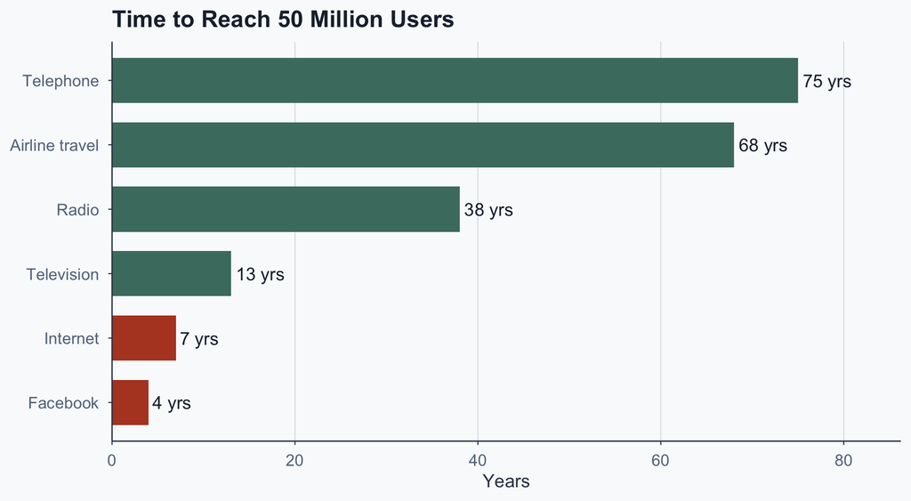

## Technology’s Paradoxes

- **Social Media**: connects billions, spreads misinformation
- **Automation**: boosts productivity, displaces workers
- **AI**: solves complex problems, concentrates power
- **Smartphones**: universal knowledge, addiction crisis

**Why does technology sometimes help and sometimes harm?**

## These Paradoxes Are Not New

Technology has reshaped society for thousands of years.

But understanding *why* requires analytical tools.

This course teaches you to think **causally** about technology and social change.

# The Analytical Toolkit

## The Core Causal Chain

This course is built around one framework:

```
%%{init: {"flowchart": {"useMaxWidth": true, "nodeSpacing": 50, "rankSpacing": 80}, "theme": "base", "themeVariables": {"fontSize": "24px", "primaryColor": "#4a7c6f", "primaryTextColor": "#f9fafb", "primaryBorderColor": "#334155", "lineColor": "#334155", "edgeLabelBackground": "#f3f4f6"}}}%%
flowchart LR
  T["Technology<br/>(material change)"] --> S["Social Change<br/>(new organization)"]
  S --> D["Development<br/>(long-run outcomes)"]
  D -.->|"feedback"| T
```

Each arrow hides complexity. Our job is to unpack it.

## Five Analytical Tools

Five tools we apply in every lecture.

| Tool | Core Question |
| --- | --- |
| **1. Causation** | Does A actually cause B? |
| **2. Mechanisms** | *How* does A cause B? |
| **3. Distribution** | Who benefits? Who loses? |
| **4. Path Dependence** | How do past choices constrain today? |
| **5. Institutions** | What rules shape technology’s effects? |

## Tool 1: Causation vs. Correlation

**Question**: Did smartphones cause loneliness?

- Smartphone use and loneliness both rose
- But lonely people may adopt phones more
- A third factor could drive both

**The point**: We need causal analysis, not just observation.

## Tool 2: Mechanisms

**Question**: *How* does automation displace workers?

Not enough to say “automation causes job loss.”

```
%%{init: {"flowchart": {"useMaxWidth": true, "nodeSpacing": 40, "rankSpacing": 60}, "theme": "base", "themeVariables": {"fontSize": "22px", "primaryColor": "#4a7c6f", "primaryTextColor": "#f9fafb", "primaryBorderColor": "#334155", "lineColor": "#334155"}}}%%
flowchart LR
  A["Automation<br/>introduced"] --> B["Machines do<br/>routine tasks"]
  B --> C["Less demand for<br/>routine workers"]
  C --> D["Workers displaced<br/>(if no new tasks)"]
```

Mechanisms tell us *where to intervene*.

## Tool 3: Distributional Analysis

**Question**: Who benefits from AI? Who loses?

Technology is never neutral.

| Winners | Losers |
| --- | --- |
| Tech firms (data + algorithms) | Routine cognitive workers |
| High-skill workers (complements) | Workers without retraining |
| Consumers (better services) | Those without digital access |

## Tool 4: Path Dependence

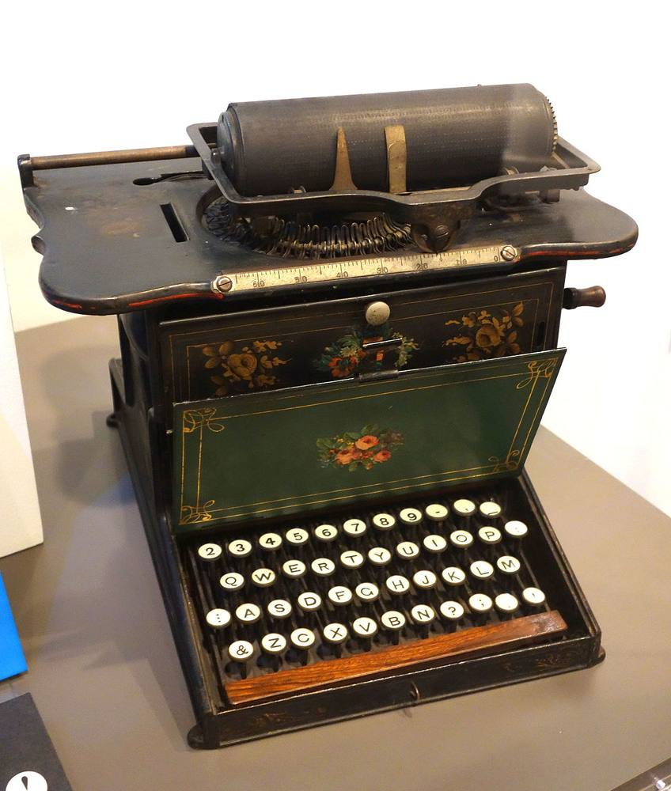

Remington No. 1 (1873). The QWERTY layout is visible on the keys. Wisconsin Historical Museum.

**Definition**: Past choices limit future options.

The QWERTY layout was designed in the 1870s to prevent mechanical type-bars from jamming.

No type-bars now—but too costly to switch.

**Why it matters**: Change is often hard even when everyone agrees it would help.

## Tool 5: Institutional Mediation

**Definition**: Rules and norms shape technology’s effects.

Same factory automation, 1920s–1950s:

- **Germany**: Strong unions negotiated retraining
- **USA**: Weaker unions, more displacement

**Key insight**: Same technology, different institutions, different outcomes.

## Practice: You Try It (2 minutes)

**Technology**: Uber / ride-sharing apps

Working with a neighbor, identify:

1. What **material constraint** changed?
2. What **new organization** emerged?
3. Who **benefits**? Who **loses**?

*We will use this example throughout the course.*

## So What?

These five tools work together to analyze any technology.

Let us test them on the most important case in human history.

**Next**: The Agricultural Revolution—where inequality began.

# The Agricultural Revolution

## Why Start with Agriculture?

The Agricultural Revolution (~10,000 BCE) is paradigmatic:

1. First major technological transformation
2. Effects span 12,000+ years
3. Patterns recur in every later revolution
4. Demonstrates all five tools clearly

Not ancient history—it is the foundation of the modern world.

## Agriculture Was Invented Independently

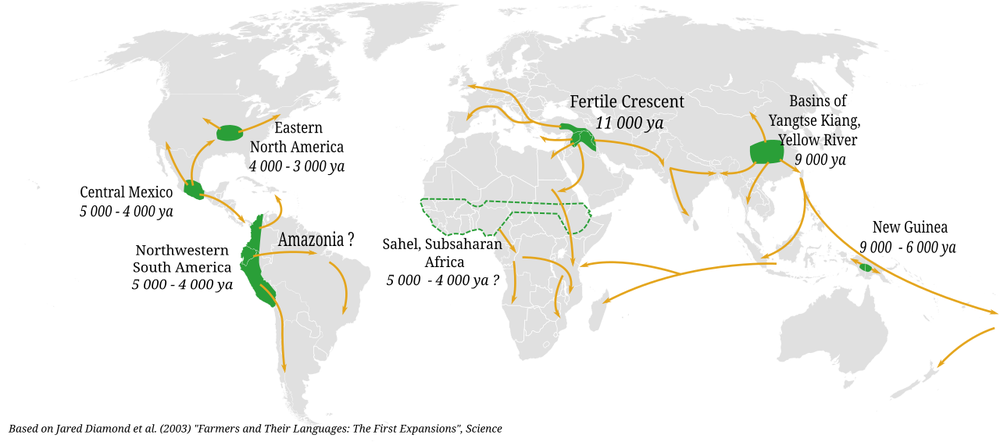

At least **eight independent origins**—not a single invention that diffused.

## What Changed?

**Before** (Hunter-Gatherers)

- Mobile groups of 20–50
- Diverse diet, wild resources
- No surplus or storage
- Relatively egalitarian

**After** (Agriculture)

- Sedentary villages, then cities
- Less diverse but predictable diet
- Surplus production and storage
- Rapid population growth

**Key**: Surplus + sedentism made new social forms *possible*—not inevitable.

## The Agricultural Paradox

> “Did we domesticate wheat, or did wheat domesticate us?” — Harari (2015)

**Gained**

- More total food
- Larger populations
- Permanent settlements
- Occupational specialization

**Lost**

- Longer work hours
- Worse nutrition (less diverse)
- New diseases (density)
- Social inequality

**Paradox**: Agriculture spread despite making most lives harder.

## Mechanism: Surplus to Stratification

```
%%{init: {"flowchart": {"useMaxWidth": true, "nodeSpacing": 40, "rankSpacing": 60}, "theme": "base", "themeVariables": {"fontSize": "22px", "primaryColor": "#4a7c6f", "primaryTextColor": "#f9fafb", "primaryBorderColor": "#334155", "lineColor": "#334155"}}}%%
flowchart LR
  A["Surplus<br/>production"] --> B["Accumulation<br/>possible"]
  B --> C["Differential<br/>wealth"]
  C --> D["Power<br/>hierarchy"]
  D --> E["Institutionalized<br/>stratification"]
```

- Foragers could not accumulate (mobility)
- Agriculture made accumulation possible
- Accumulation produced permanent inequality

**Lesson**: Technology enables new forms of *power*.

## Mechanism: The Population Trap

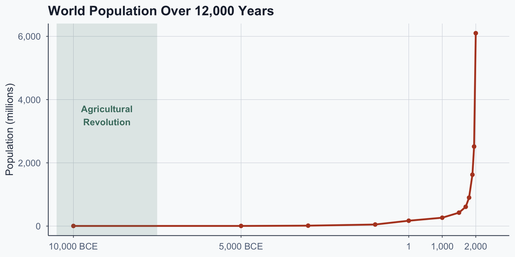

Figure 2: World population (millions). Long-run historical points from Kremer (1993, Table I; based on McEvedy & Jones for early periods); 10,000 BCE anchor consistent with HYDE 3.2 global estimate (~4.4M); 2000 level consistent with UN Population Division (~6.1B in mid-2000).

More food –> population grows –> more farming –> **cannot go back**. This is path dependence.

## Who Won? Who Lost?

Distributional consequences of the Agricultural Revolution.

| Winners | Losers |
| --- | --- |
| Those who controlled land | Agricultural laborers |
| Political and religious elites | Conquered peoples |
| Military specialists | Women (in many societies) |
| Merchants in surplus economy | Those with worse health |

**Insight**: Technological change *always* redistributes power.

## Institutions That Persisted

Agriculture created remarkably durable institutions:

- **Property rights** in land
- **Taxation** systems (extracting surplus)
- **Coercive labor** (corvee, slavery, serfdom)
- **Political hierarchy** (kings, priests, bureaucrats)

Why? Beneficiaries resist change. New institutions build on old ones. Norms reinforce structures.

## The Spread of Farming Was Gradual and Uneven

[figure not shown]

Expansion of farming in western Eurasia, 9600–4000 BCE. Dates show centuries of first adoption. Map: Gronenborn, Horejs, Börner & Ober (LEIZA/ÖAI).

## The Long Shadow of Agriculture

Putterman & Weil (2010): longer agricultural history correlates with higher GDP today.

- 1,000 extra years of farming –> ~5–6% higher income

**Mechanism**: agriculture –> surplus –> specialization –> states –> infrastructure –> growth

**Open debate**: Geography vs. institutions vs. culture? (Lecture 4)

## So What?

The Agricultural Revolution demonstrates our entire toolkit:

1. **Causation**: agriculture *caused* stratification
2. **Mechanisms**: surplus chain + population trap
3. **Distribution**: clear winners and losers
4. **Path dependence**: population growth locked in choices
5. **Institutions**: rules crystallized and persisted

**Next**: Does this same pattern repeat across revolutions?

# Patterns Across Revolutions

## Four Great Technological Revolutions

```
%%{init: {"flowchart": {"useMaxWidth": true, "nodeSpacing": 30, "rankSpacing": 50}, "theme": "base", "themeVariables": {"fontSize": "20px", "primaryColor": "#4a7c6f", "primaryTextColor": "#f9fafb", "primaryBorderColor": "#334155", "lineColor": "#334155"}}}%%
flowchart LR
  A["Cognitive<br/>~70,000 BCE<br/>Language,<br/>cooperation"] --> B["Agricultural<br/>~10,000 BCE<br/>Surplus,<br/>hierarchy"]
  B --> C["Industrial<br/>~1760-1840<br/>Mechanization,<br/>cities"]
  C --> D["Digital<br/>~1970-present<br/>Computation,<br/>AI"]
```

Each followed a recognizable pattern.

## So What?

The same pattern—from agriculture to AI—keeps recurring.

Recognizing patterns is not enough. You need to think critically.

**Next**: Three questions to protect you from bad arguments.

# Thinking Like an Analyst

## Intended vs. Unintended Consequences

**Social media**: designed to connect, amplified misinformation

**Agriculture**: adopted to reduce hunger, trapped by population growth

**Why this happens**:

- Complex systems produce emergent properties
- Individual rationality does not equal collective optimality
- Institutions persist beyond their original purpose

## Three Common Analytical Mistakes

**1. Technological determinism**

*“AI will inevitably eliminate jobs”* — Effects depend on institutions and policy.

**2. Confusing correlation with causation**

*“Social media and depression rose together”* — Identify mechanisms first.

**3. Ignoring distribution**

*“Technology benefits society”* — Which parts of society, specifically?

## So What?

Critical thinking separates analysis from description.

These questions will guide every reading and discussion.

**Next**: A roadmap for the semester ahead.

# Where We Go From Here

## The Course Roadmap

```
%%{init: {"flowchart": {"useMaxWidth": true, "nodeSpacing": 40, "rankSpacing": 60}, "theme": "base", "themeVariables": {"fontSize": "20px", "primaryColor": "#4a7c6f", "primaryTextColor": "#f9fafb", "primaryBorderColor": "#334155", "lineColor": "#334155"}}}%%
flowchart LR
  A["Foundations<br/>L1-L2"] --> B["Historical Cases<br/>L3-L5, L8"]
  B --> C["Theory of<br/>Technology - L9"]
  C --> D["Contemporary<br/>L11, L13-L15"]
```

Each lecture applies the five analytical tools from today.

## Why This Matters to You

**You are living through a technological revolution right now.**

In 50 years, will historians say the Digital Revolution:

- Created unprecedented opportunity?
- Created a new “trap” like agriculture?
- Both?

**Your generation will shape the answer.** This course gives you the tools to understand the stakes.

## References

Harari, Y. N. (2015). *Sapiens: A brief history of humankind*. Harper.

Kremer, M. (1993). Population growth and technological change: One million B.C. to 1990. *The Quarterly Journal of Economics*, *108*(3), 681–716.

Putterman, L., & Weil, D. N. (2010). Post-1500 population flows and the long-run determinants of economic growth and inequality. *The Quarterly Journal of Economics*, *125*(4), 1627–1682.